# Página Html - COVID

Lucas Antonio

30/06/2020

Análise de Dados feita com a linguagem de programação R, a partir do minicurso “Análise e Visualização de dados da COVID-19”, lecionado pelo professor Marcus Carvalho.

# Brasil

Abaixo estarão os dados referente aos casos do Brasil. Dividindo em diferentes tipos de dados, como “Casos no Brasil”, “Óbitos no Brasil”, entre outros.

## Casos Acumulados

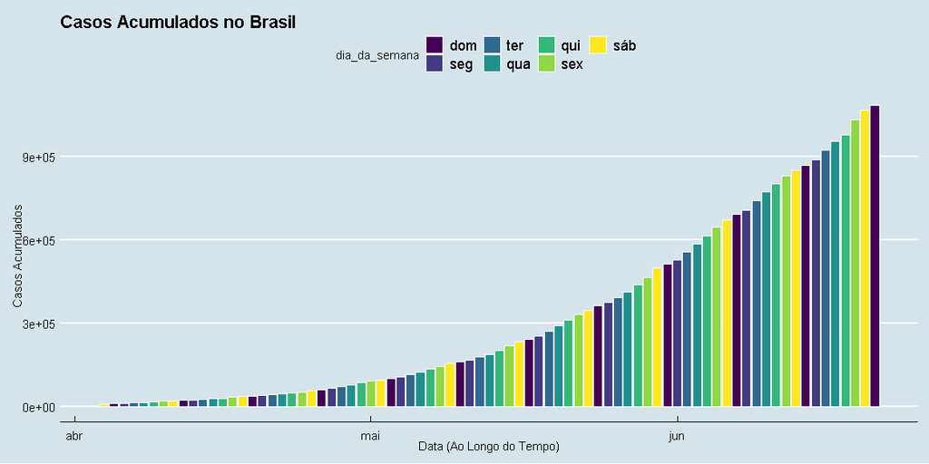

## Óbitos Acumulados

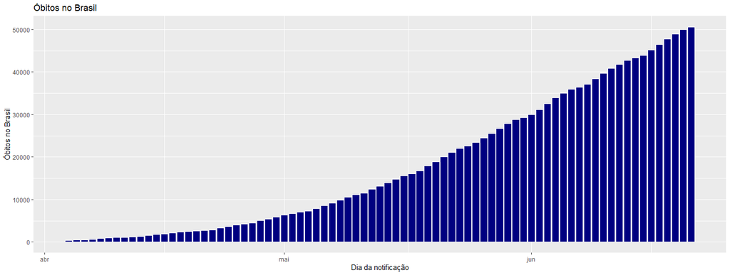

## Óbitos acumulados no Brasil (Dia da Semana)

É o mesmo gráfico, mas, está detalhado com os dias da semana.

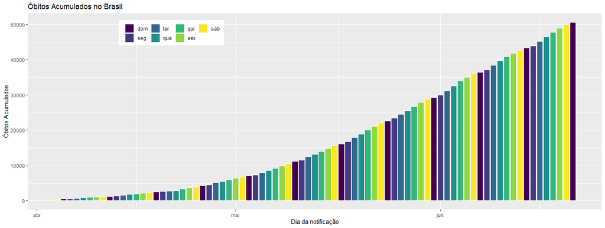

Anteriormente vimos os dados no final de Junho. Agora, vamos dar uma olhada até o começo de agosto, analisando a diferenciação entre os dois.

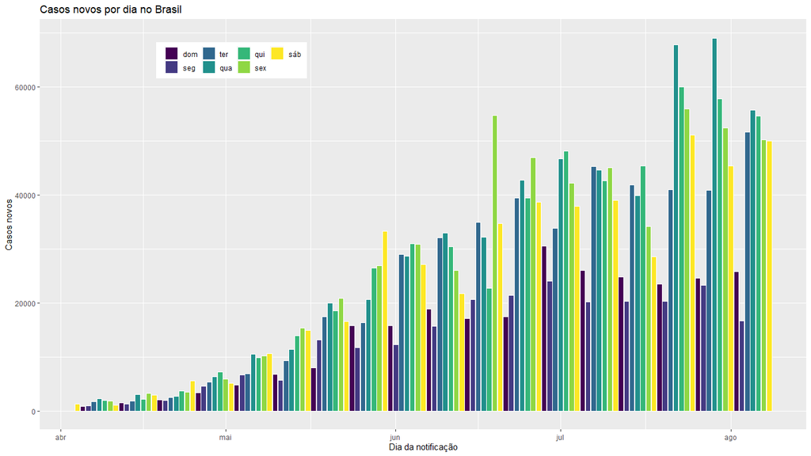

# Regiões

## Casos acumulados por região

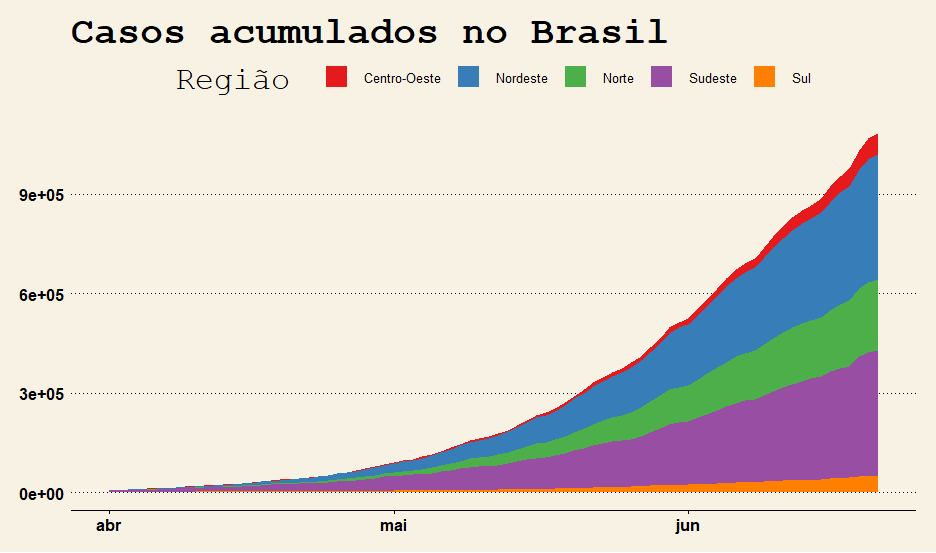

### Casos acumulados por região (Até começo de Agosto)

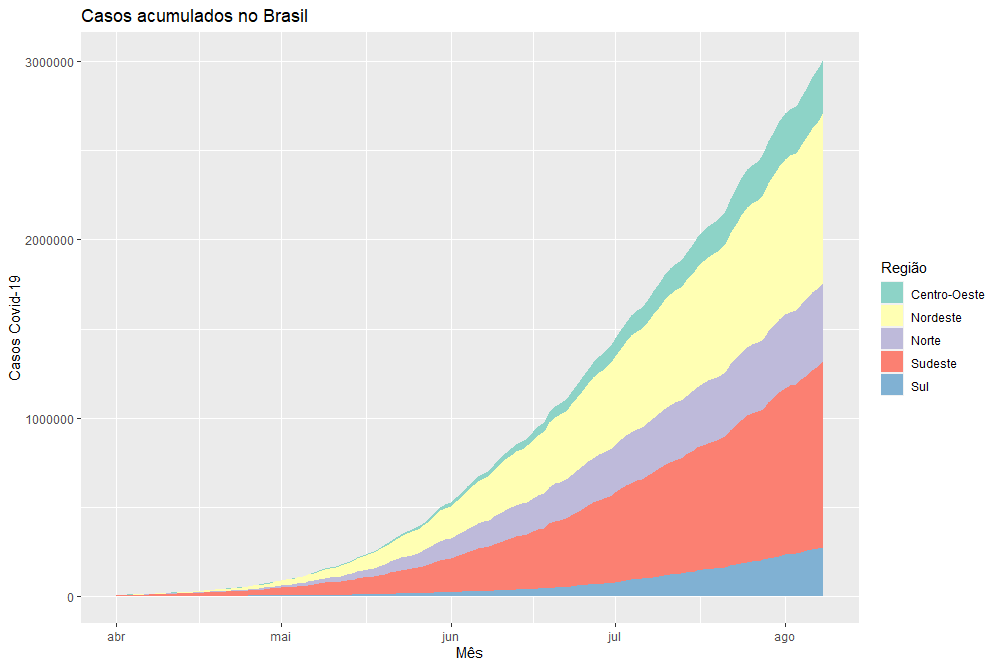

### Óbitos por região

#### Óbitos acumulados por região

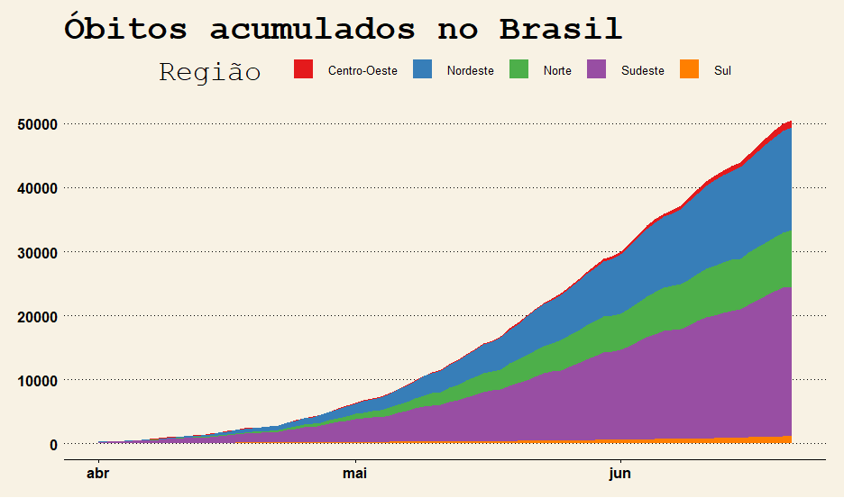

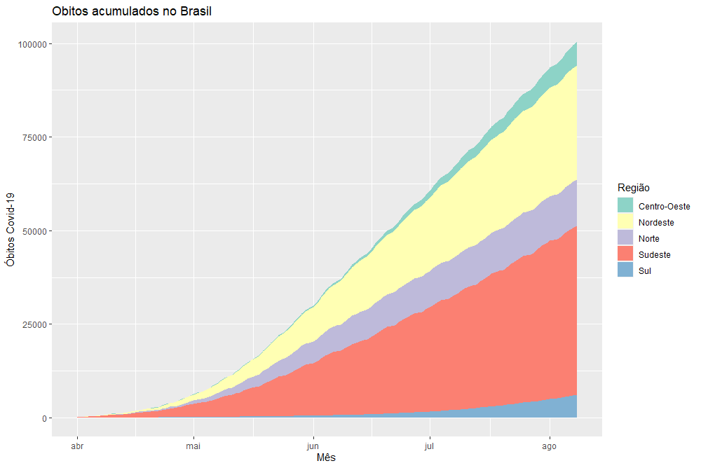

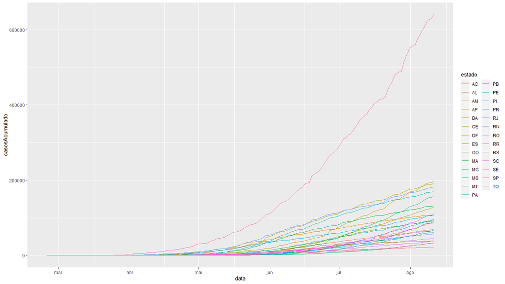

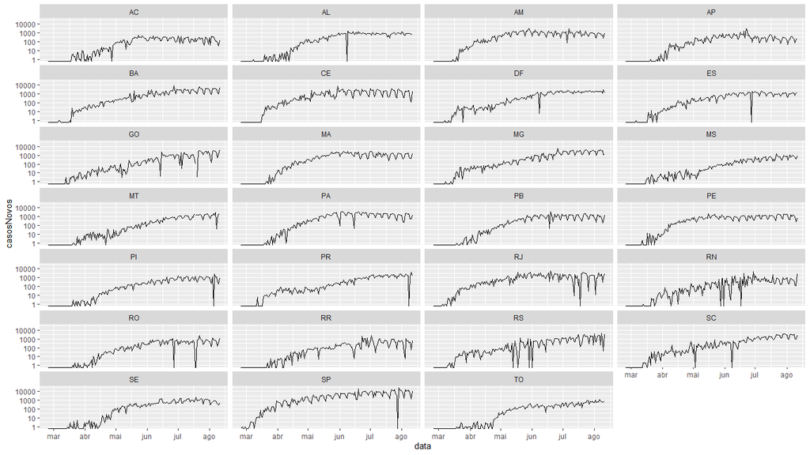

# Agradecimentos

Agradeço à Marcus Carvalho (Orientador) pela oportunidade de ter realizado esse trabalho. Por mais que não tive como focar 100% devido a problemas externos (impactando assim neste trabalho), sinto que o curso me deu um bom retorno.